# Minería de datos: PEC2 - Métodos no supervisados

Autor: Alejandro Sánchez Gómez

Octubre 2023

# Ejercicios

Los ejercicios se realizarán en base al juego de datos *Hawks* presente en el paquete R *Stat2Data*.

Los estudiantes y el profesorado del Cornell College en Mount Vernon, Iowa, recogieron datos durante muchos años en el mirador de halcones del lago MacBride, cerca de Iowa City, en el estado de Iowa. El conjunto de datos que analizamos aquí es un subconjunto del conjunto de datos original, utilizando sólo aquellas especies para las que había más de 10 observaciones. Los datos se recogieron en muestras aleatorias de tres especies diferentes de halcones: Colirrojo, Gavilán y Halcón de Cooper.

Hemos seleccionado este juego de datos por su parecido con el juego de datos *penguins* y por su potencial a la hora de aplicarle algoritmos de minería de datos no supervisados. Las variables numéricas en las que os basaréis son: *Wing*, *Weight*, *Culmen*, *Hallux*

```r
if (!require('Stat2Data')) install.packages('Stat2Data')
library(Stat2Data)
data("Hawks")
summary(Hawks)
```

```
##      Month             Day             Year       CaptureTime   ReleaseTime
##  Min.   : 8.000   Min.   : 1.00   Min.   :1992   11:35  : 14          :842
##  1st Qu.: 9.000   1st Qu.: 9.00   1st Qu.:1995   13:30  : 14   11:00  :  2
##  Median :10.000   Median :16.00   Median :1999   11:45  : 13   11:35  :  2
##  Mean   : 9.843   Mean   :15.74   Mean   :1998   12:10  : 13   12:05  :  2
##  3rd Qu.:10.000   3rd Qu.:23.00   3rd Qu.:2001   14:00  : 13   12:50  :  2
##       BandNumber  Species  Age     Sex          Wing           Weight
##            :  2   CH: 70   A:224    :576   Min.   : 37.2   Min.   :  56.0
##  1142-09240:  1   RT:577   I:684   F:174   1st Qu.:202.0   1st Qu.: 185.0
##  1142-09241:  1   SS:261           M:158   Median :370.0   Median : 970.0
##  1142-09242:  1                            Mean   :315.6   Mean   : 772.1
##  1142-18229:  1                            3rd Qu.:390.0   3rd Qu.:1120.0
##      Culmen         Hallux            Tail        StandardTail
##  Min.   : 8.6   Min.   :  9.50   Min.   :119.0   Min.   :115.0
##  1st Qu.:12.8   1st Qu.: 15.10   1st Qu.:160.0   1st Qu.:162.0
##  Median :25.5   Median : 29.40   Median :214.0   Median :215.0
##  Mean   :21.8   Mean   : 26.41   Mean   :198.8   Mean   :199.2
##  3rd Qu.:27.3   3rd Qu.: 31.40   3rd Qu.:225.0   3rd Qu.:226.0
##      Tarsus        WingPitFat        KeelFat           Crop
##  Min.   :24.70   Min.   :0.0000   Min.   :0.000   Min.   :0.0000
##  1st Qu.:55.60   1st Qu.:0.0000   1st Qu.:2.000   1st Qu.:0.0000
##  Median :79.30   Median :1.0000   Median :2.000   Median :0.0000
##  Mean   :71.95   Mean   :0.7922   Mean   :2.184   Mean   :0.2345
##  3rd Qu.:87.00   3rd Qu.:1.0000   3rd Qu.:3.000   3rd Qu.:0.2500
##  [ reached getOption("max.print") -- omitted 2 rows ]
```

## Ejercicio 1

Presenta el juego de datos, nombre y significado de cada columna, así como las distribuciones de sus valores.

Realiza un estudio aplicando el método K-means, similar al de los ejemplos 1.1 y 1.2

### Respuesta 1

Los ejercicios se realizarán en base al juego de datos *Hawks* presente en el paquete R *Stat2Data*.

Este dataset está previamente trabajado para que los datos estén limpios y sin errores. De no ser así, se debería buscar errores, valores nulos u outliers. Deberíamos tratar de discretizar o eliminar columnas. Incluso realizar este último paso varias veces para comprobar los diferentes resultados y elegir el que mejor rendimiento nos dé. De todos modos contiene algún valor nulo que trataremos más adelante.

```r
str(Hawks)
```

```
## 'data.frame':    908 obs. of  19 variables:
##  $ Month       : int  9 9 9 9 9 9 9 9 9 9 ...
##  $ Day         : int  19 22 23 23 27 28 28 29 29 30 ...
##  $ Year        : int  1992 1992 1992 1992 1992 1992 1992 1992 1992 1992 ...
##  $ CaptureTime : Factor w/ 308 levels " ","1:15","1:31",..: 181 25 138 42 62 71 181 88 261 192 ...
##  $ ReleaseTime : Factor w/ 60 levels ""," ","10:20",..: 1 2 2 2 2 2 2 2 2 2 ...
##  $ BandNumber  : Factor w/ 907 levels " ","1142-09240",..: 856 857 858 809 437 280 859 860 861 281 ...
##  $ Species     : Factor w/ 3 levels "CH","RT","SS": 2 2 2 1 3 2 2 2 2 2 ...
##  $ Age         : Factor w/ 2 levels "A","I": 2 2 2 2 2 2 2 1 1 2 ...
##  $ Sex         : Factor w/ 3 levels "","F","M": 1 1 1 2 2 1 1 1 1 1 ...
##  $ Wing        : num  385 376 381 265 205 412 370 375 412 405 ...
##  $ Weight      : int  920 930 990 470 170 1090 960 855 1210 1120 ...
##  $ Culmen      : num  25.7 NA 26.7 18.7 12.5 28.5 25.3 27.2 29.3 26 ...
##  $ Hallux      : num  30.1 NA 31.3 23.5 14.3 32.2 30.1 30 31.3 30.2 ...
##  $ Tail        : int  219 221 235 220 157 230 212 243 210 238 ...
##  $ StandardTail: int  NA NA NA NA NA NA NA NA NA NA ...
##  $ Tarsus      : num  NA NA NA NA NA NA NA NA NA NA ...
##  $ WingPitFat  : int  NA NA NA NA NA NA NA NA NA NA ...
##  $ KeelFat     : num  NA NA NA NA NA NA NA NA NA NA ...
##  $ Crop        : num  NA NA NA NA NA NA NA NA NA NA ...
```

El juego de datos cuenta con *908 observaciones* y *19 variables*. A continuación, presentaremos las variables:

- *Month* = Mes de la observación. Siendo 1 = Enero, …, 12 = Diciembre.
- *Day* = Día (1-31) del mes de la observación.
- *Year* = Año (1992-2003) de la observación.
- *CaptureTime* = Tiempo de captura (HH:MM).
- *ReleaseTime* = Tiempo de liberación (HH:MM).
- *BandNumber* = Código de identificación de la banda.
- *Species* = CH = Halcón de Cooper, RT = Colirrojo, SS = Gavilán.
- *Age* = A = Adulto, I = Inmaduro.
- *Sex* = F = Mujer, M = Hombre.
- *Wing* = Longitud (mm) de la pluma primaria del ala desde la punta hasta la muñeca a la que se une.
- *Weight* = Peso (g).
- *Culmen* = Longitud (mm) de la parte superior del pico desde la punta hasta la parte carnosa del ave.
- *Hallux* = Longitud (mm) de la garra.
- *Tail* = Medida (mm) relativa a la longitud de la cola.
- *StandardTail* = Medida estandarizada de la longitud de la cola (mm).
- *Tarsus* = Longitud del hueso básico del pie (mm).
- *WingPitFat* = Cantidad de grasa en el hueso del ala.
- *KeelFat* = Cantidad de grasa en el esternón.
- *Crop* = Cantidad de material en el buche, codificada de 1=lleno a 0=vacío.

El enunciado nos plantea clasificar mediante el método no supervisado k-means las diferentes especies en función de las variables *Wing*, *Weight*, *Culmen* y *Hallux*. Por lo tanto, eliminaremos el resto de variables que no sean las antes descritas:

```r
df <- Hawks[, c('Wing', 'Weight', 'Culmen', 'Hallux')]
df
```

```
##    Wing Weight Culmen Hallux
## 1   385    920   25.7   30.1
## 2   376    930     NA     NA
## 3   381    990   26.7   31.3
## 4   265    470   18.7   23.5
## 5   205    170   12.5   14.3
## 6   412   1090   28.5   32.2
## 7   370    960   25.3   30.1
## 8   375    855   27.2   30.0
## 9   412   1210   29.3   31.3
## 10  405   1120   26.0   30.2
## 11  393   1010   26.3   30.8
## 12  371   1010   25.4   29.7
## 13  390   1120   28.9   30.9
## 14  393     NA   28.2   30.6
## 15  416   1170   26.5   34.0
## 16  436   1390   30.5   34.0
## 17  418   1150   27.1   31.0
## 18  381    950   28.9   28.9
## 19  378    910   25.7   28.2
## 20  396   1010   24.0   26.9
## 21  399   1070   26.4   31.2
## 22  416   1190   28.8   31.6
## 23  415    101   24.9   30.7
## 24  392   1330   27.0   30.3
## 25  380    990   26.0   30.0
##  [ reached 'max' / getOption("max.print") -- omitted 883 rows ]
```

A continuación, eliminaremos los valores no disponibles para que estos no interfieran en la construcción del modelo:

```r
if (!require('dplyr')) install.packages('dplyr')
library(dplyr)

df <- na.omit(df)
df
```

```
##    Wing Weight Culmen Hallux
## 1   385    920   25.7   30.1
## 3   381    990   26.7   31.3
## 4   265    470   18.7   23.5
## 5   205    170   12.5   14.3
## 6   412   1090   28.5   32.2
## 7   370    960   25.3   30.1
## 8   375    855   27.2   30.0
## 9   412   1210   29.3   31.3
## 10  405   1120   26.0   30.2
## 11  393   1010   26.3   30.8
## 12  371   1010   25.4   29.7
## 13  390   1120   28.9   30.9
## 15  416   1170   26.5   34.0
## 16  436   1390   30.5   34.0
## 17  418   1150   27.1   31.0
## 18  381    950   28.9   28.9
## 19  378    910   25.7   28.2
## 20  396   1010   24.0   26.9
## 21  399   1070   26.4   31.2
## 22  416   1190   28.8   31.6
## 23  415    101   24.9   30.7
## 24  392   1330   27.0   30.3
## 25  380    990   26.0   30.0
## 27  399   1100   26.2   32.5
## 28  401   1190   28.6   31.6
##  [ reached 'max' / getOption("max.print") -- omitted 866 rows ]
```

Ahora procedemos a deducir el número de clúster que necesitamos. La primera técnica a emplear es calcular el valor de las siluetas media:

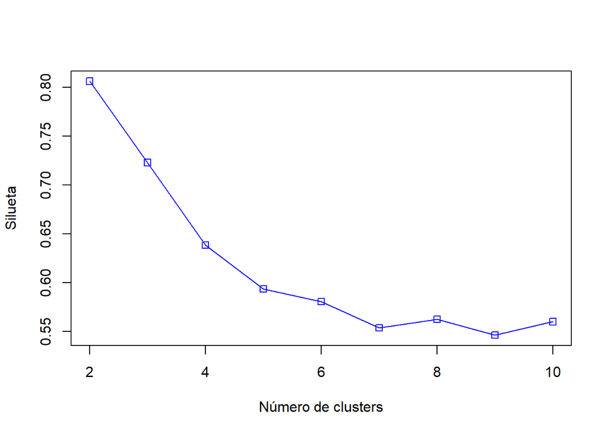

```r
if (!require('cluster')) install.packages('cluster')
library('cluster')

d <- daisy(df)
resultados <- rep(0, 10)
for(i in c(2, 3, 4, 5, 6, 7, 8, 9, 10)){
  fit <- kmeans(df, i)
  y_cluster <- fit$cluster
  sk <- silhouette(y_cluster, d)
  resultados[i] <- mean(sk[,3])
}
plot(2:10,resultados[2:10],type="o",col="blue",pch=0,xlab="Número de clusters",ylab="Silueta")
```

Observamos que el modelo comienza a presentar una menor desviación a partir de k=6.

Puesto que sabemos que el valor de k debería ser 3, probaremos a buscar un mejor modelo. Para ello, usaremos aquel que ofrece la menor suma de los cuadrados de las distancias de los puntos de cada grupo con respecto a su centro (withinss), con la mayor separación entre centros de grupos (betweenss).

La selección del número de clústers se basará en emplear el método *elbow* (codo), que no es más que la selección del número de clústers en base a la inspección de la gráfica que se obtiene al iterar con el mismo conjunto de datos para distintos valores del número de clústers.

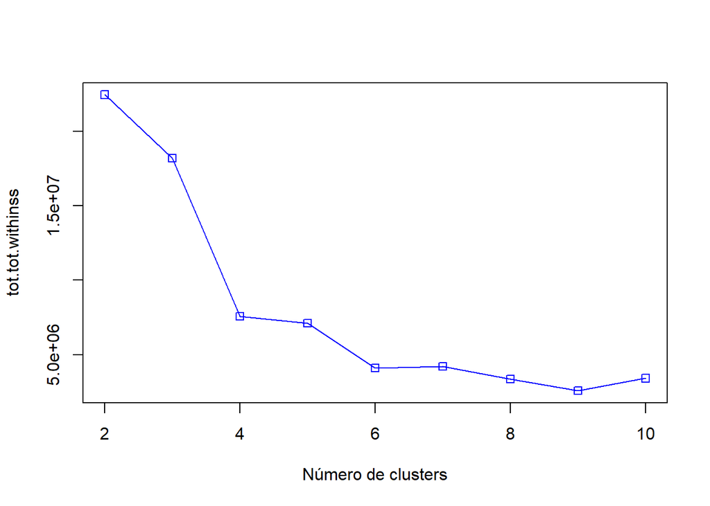

```r
resultados <- rep(0, 10)
for (i in c(2,3,4,5,6,7,8,9,10))
{
  fit           <- kmeans(df, i)
  resultados[i] <- fit$tot.withinss
}
plot(2:10,resultados[2:10],type="o",col="blue",pch=0,xlab="Número de clusters",ylab="tot.tot.withinss")
```

En este caso, el número de clústers óptimo es 4, pues la curva comienza a estabilizarse.

Aplicaremos otro método de validación. En este caso la función kmeansruns, del paquete fpc. Éste ejecuta el algoritmo kmeans con un conjunto de valores, para después seleccionar el valor del número de clústers que mejor funcione de acuerdo a dos criterios: la silueta media (“asw”) y Calinski-Harabasz (“ch”).

```r
if (!require('fpc')) install.packages('fpc')
library(fpc)
fit_ch  <- kmeansruns(df, krange = 1:10, criterion = "ch")
fit_asw <- kmeansruns(df, krange = 1:10, criterion = "asw")
```

Inspeccionemos la silueta media y Calinski-Harabasz respectivamente:

```r
fit_ch$bestk
```

```
## [1] 10
```

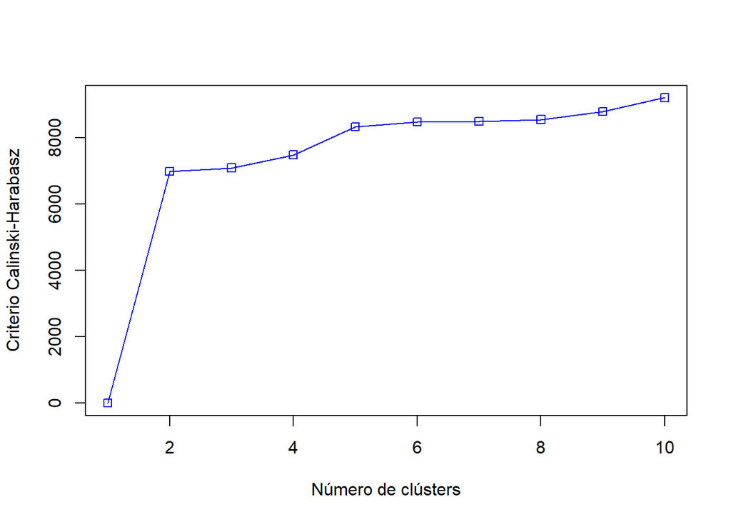

```r
plot(1:10,fit_ch$crit,type="o",col="blue",pch=0,xlab="Número de clústers",ylab="Criterio Calinski-Harabasz")
```

```r
fit_asw$bestk
```

```
## [1] 2
```

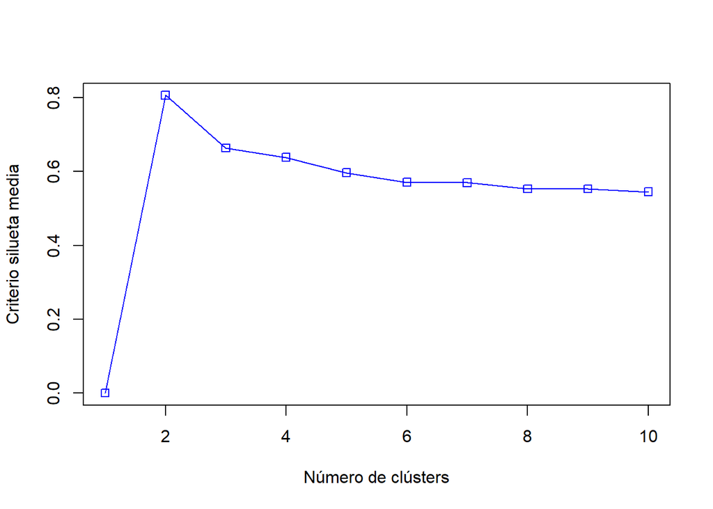

```r
plot(1:10,fit_asw$crit,type="o",col="blue",pch=0,xlab="Número de clústers",ylab="Criterio silueta media")
```

Obtamos por 3 clústers debido a que sabemos préviamente el número de clústers ideales. De lo contrario, la tarea no sería sencilla y quedaría a validación externa cuál es el más óptimo.

A continuación, agruparemos dos variables mediante k-means y luego lo compararemos con el valor real para determinar que variables determinan que halcón pertenece a una espécie u otra.

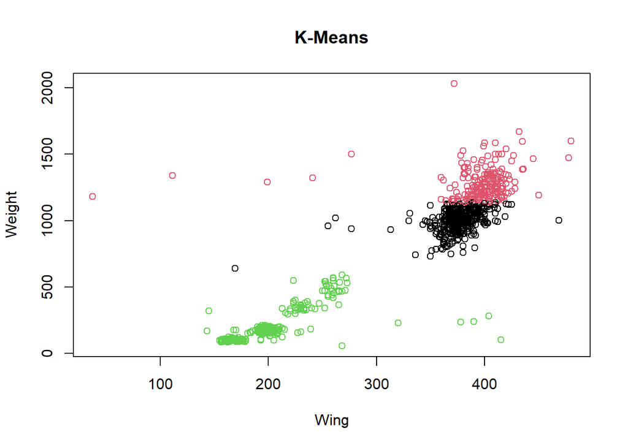

```r
hawks3clusters <- kmeans(df, 3)

#Wing y Weight
wing_weight = df[c(1, 2)]
plot(wing_weight, col=hawks3clusters$cluster, main="K-Means")
```

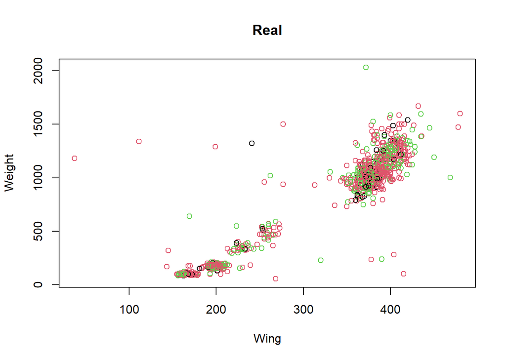

```r
plot(wing_weight, col=as.factor(Hawks$Species), main="Real")
```

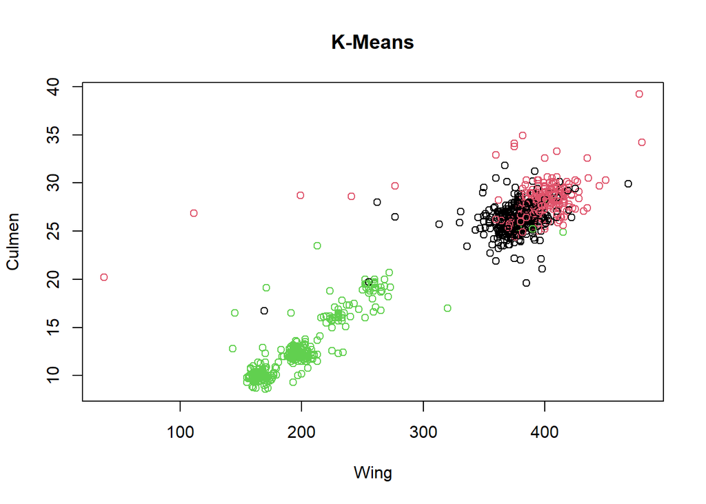

```r
#Wing y Culmen
wing_culmen = df[c(1, 3)]
plot(wing_culmen, col=hawks3clusters$cluster, main="K-Means")
```

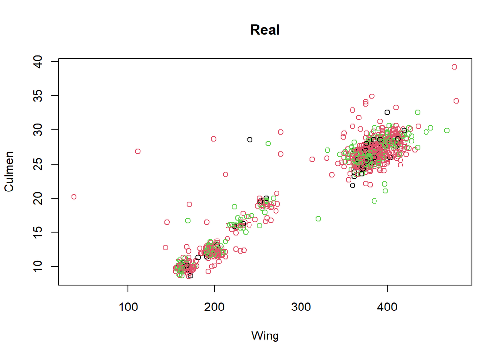

```r
plot(wing_culmen, col=as.factor(Hawks$Species), main="Real")
```

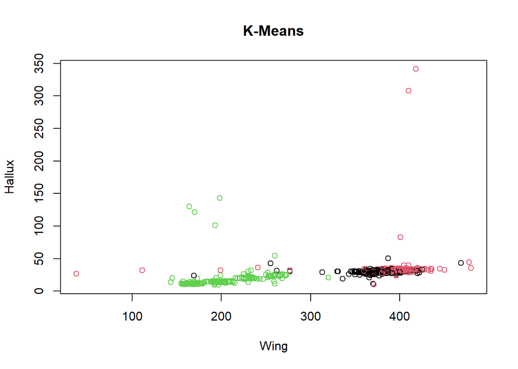

```r
#Wing y Hallax
wing_hallax = df[c(1, 4)]
plot(wing_hallax, col=hawks3clusters$cluster, main="K-Means")
```

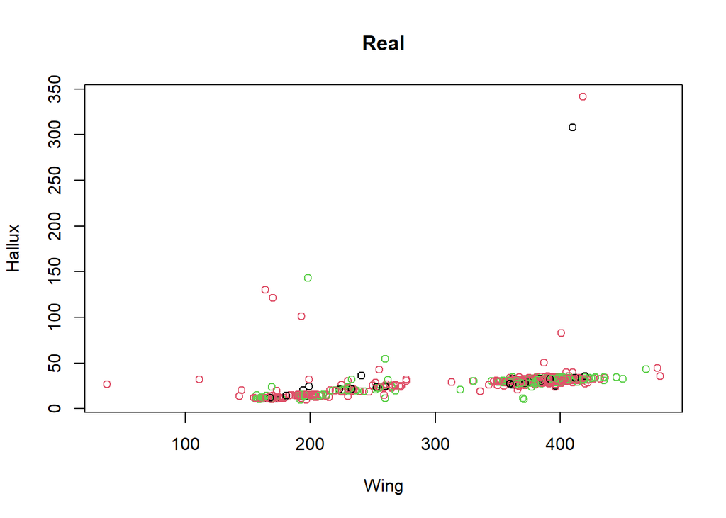

```r
plot(wing_hallax, col=as.factor(Hawks$Species), main="Real")
```

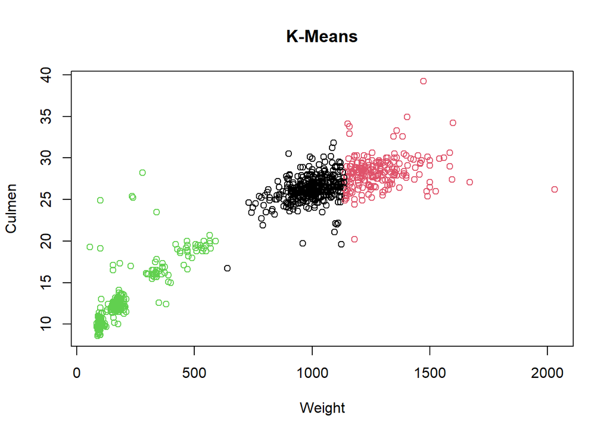

```r
#Weight y Culmen
weight_culmen = df[c(2, 3)]
plot(weight_culmen, col=hawks3clusters$cluster, main="K-Means")
```

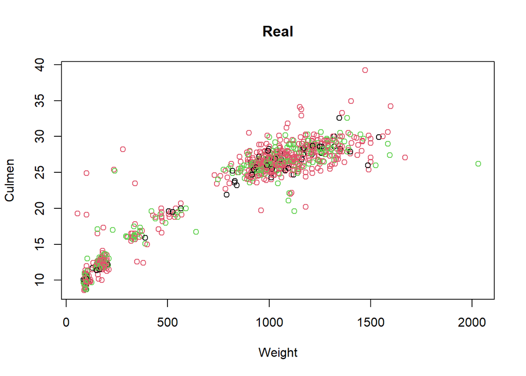

```r
plot(weight_culmen, col=as.factor(Hawks$Species), main="Real")
```

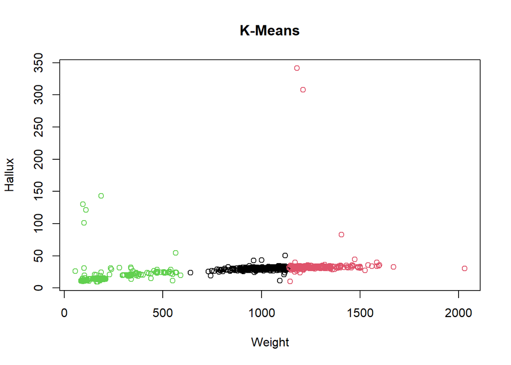

```r
#Weight y Hallax
weight_hallax = df[c(2, 4)]
plot(weight_hallax, col=hawks3clusters$cluster, main="K-Means")
```

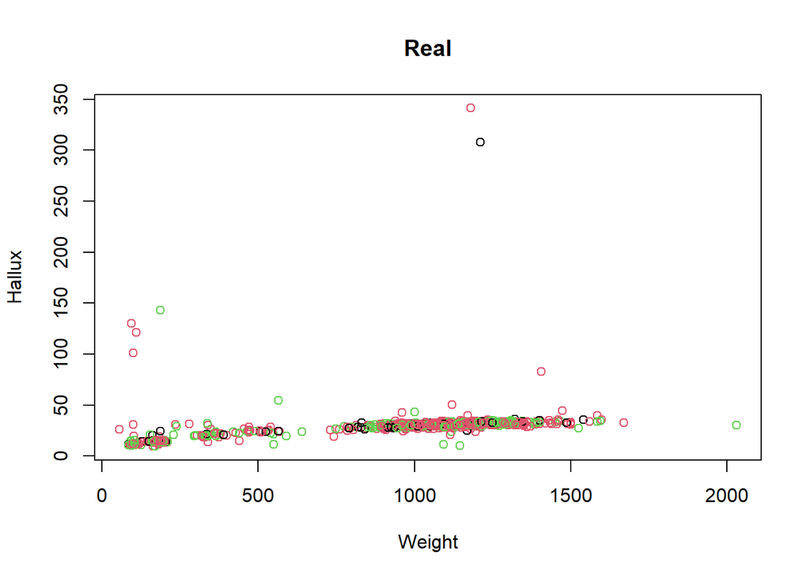

```r
plot(weight_hallax, col=as.factor(Hawks$Species), main="Real")
```

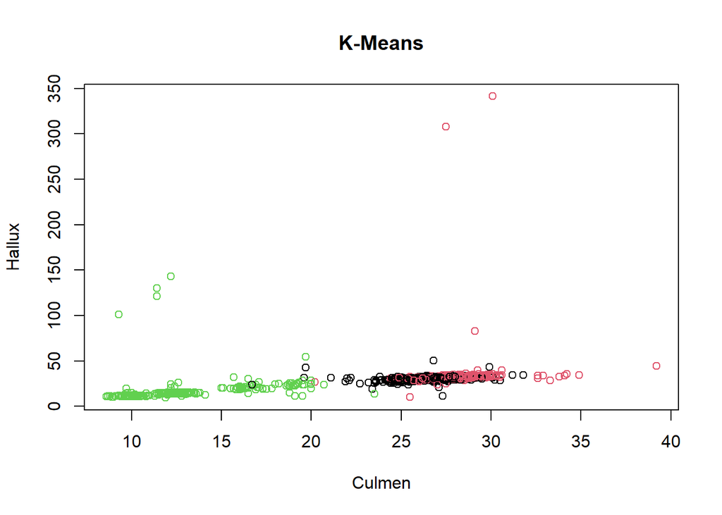

```r
#Culmen y Hallax
culmen_hallax = df[c(3, 4)]
plot(culmen_hallax, col=hawks3clusters$cluster, main="K-Means")
```

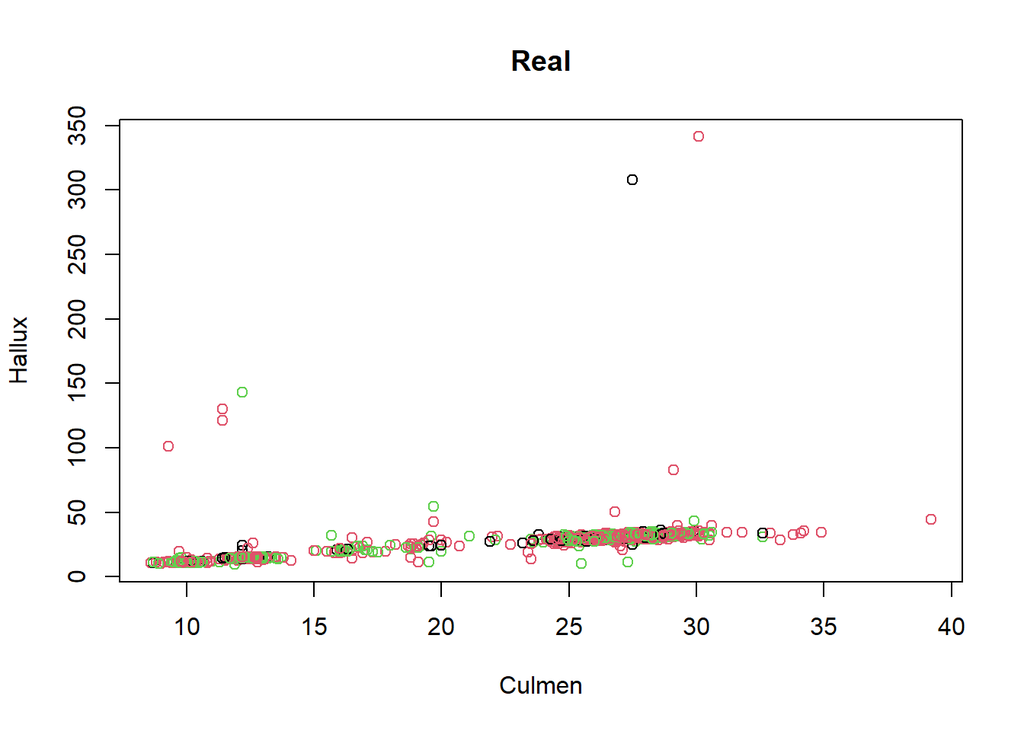

```r
plot(culmen_hallax, col=as.factor(Hawks$Species), main="Real")
```

## Ejercicio 2

Con el juego de datos proporcionado realiza un estudio aplicando DBSCAN y OPTICS, similar al del ejemplo 2

### Respuesta 2

A continuación, vamos ha trabajar los algoritmos DBSCAN y OPTICS como métodos de clustering que permiten la generación de grupos no radiales a diferencia de k-means. Veremos que su parámetro de entrada más relevante es minPts que define la mínima densidad aceptada alrededor de un centroide. Incrementar este parámetro nos permitirá reducir el ruido (observaciones no asignadas a ningún cluster).

Instalamos las librerías necesarias:

```r
if (!require('dbscan')) install.packages('dbscan')
library(dbscan)
```

Normalizamos el conjunto de datos:

```r
df$Wing <- scale(df$Wing, center = min(df$Wing), scale = max(df$Wing) - min(df$Wing))
df$Weight <- scale(df$Weight, center = min(df$Weight), scale = max(df$Weight) - min(df$Weight))
df$Culmen <- scale(df$Culmen, center = min(df$Culmen), scale = max(df$Culmen) - min(df$Culmen))
df$Hallux <- scale(df$Hallux, center = min(df$Hallux), scale = max(df$Hallux) - min(df$Hallux))
```

Creamos los pares para realizar el estudio:

```r
wing_weight = df[c(1, 2)]
wing_culmen = df[c(1, 3)]
wing_hallax = df[c(1, 4)]
weight_culmen = df[c(2, 3)]
weight_hallax = df[c(2, 4)]
culmen_hallax = df[c(3, 4)]
```

#### OPTICS

Una de las primeras actividades que realiza el algoritmo es ordenar las observaciones de forma que los puntos más cercanos se conviertan en vecinos en el ordenamiento. Se podría pensar como una representación numérica del dendograma de una agrupación jerárquica.

Lanzamos el algoritmo OPTICS dejando el parámetro eps con su valor por defecto y fijando el criterio de vecindad en 10:

```r
res_wing_weight <- optics(wing_weight, minPts = 10)
res_wing_weight
```

```
## OPTICS ordering/clustering for 891 objects.
## Parameters: minPts = 10, eps = 0.564691693714801, eps_cl = NA, xi = NA
## Available fields: order, reachdist, coredist, predecessor, minPts, eps,
##                   eps_cl, xi
```

```r
res_wing_culmen <- optics(wing_culmen, minPts = 10)
res_wing_culmen
```

```
## OPTICS ordering/clustering for 891 objects.
## Parameters: minPts = 10, eps = 0.409026103626258, eps_cl = NA, xi = NA
## Available fields: order, reachdist, coredist, predecessor, minPts, eps,
##                   eps_cl, xi
```

```r
res_wing_hallax <- optics(wing_hallax, minPts = 10)
res_wing_hallax
```

```
## OPTICS ordering/clustering for 891 objects.
## Parameters: minPts = 10, eps = 0.908887026048843, eps_cl = NA, xi = NA
## Available fields: order, reachdist, coredist, predecessor, minPts, eps,
##                   eps_cl, xi
```

```r
res_weight_culmen <- optics(weight_culmen, minPts = 10)
res_weight_culmen
```

```
## OPTICS ordering/clustering for 891 objects.
## Parameters: minPts = 10, eps = 0.287406004752579, eps_cl = NA, xi = NA
## Available fields: order, reachdist, coredist, predecessor, minPts, eps,
##                   eps_cl, xi
```

```r
res_weight_hallax <- optics(weight_hallax, minPts = 10)
res_weight_hallax
```

```
## OPTICS ordering/clustering for 891 objects.
## Parameters: minPts = 10, eps = 0.907724416965764, eps_cl = NA, xi = NA
## Available fields: order, reachdist, coredist, predecessor, minPts, eps,
##                   eps_cl, xi
```

```r
res_culmen_hallax <- optics(culmen_hallax, minPts = 10)
res_culmen_hallax
```

```
## OPTICS ordering/clustering for 891 objects.
## Parameters: minPts = 10, eps = 0.920257988568104, eps_cl = NA, xi = NA
## Available fields: order, reachdist, coredist, predecessor, minPts, eps,
##                   eps_cl, xi
```

Obtenemos la ordenación de las observaciones o puntos:

```r
res_wing_weight$order
```

```
##   [1]   1 555 717 515 278 811 663 563 491 413 754 845 729 839 634 860 762 467
##  [19] 397 197 473 748 589 855 604 501 469 326 179 108  88  23   2 113 807 270
##  [37] 375 118 114  11 380 262 238 111  87 130 699 773 685 566 565 516 457 414
##  [55] 150 426 286 216 308 881 846 828 632 599 531 453 134  74   6 410 742 633
##  [73] 727 573 746 650 492 451 368 284 185  45 591 243 175 446 188 771 362  82
##  [91] 832 577 226 141 344 816 808 596 585 324
##  [ reached getOption("max.print") -- omitted 791 entries ]
```

```r
res_wing_culmen$order
```

```
##   [1]   1 808 758 555 847 441 253 249 179 174 145 130  40 536 380 177 270 149
##  [19] 110 243 515 666 475 777 443 228 172 459 258 160 126  67 132 421 191 187
##  [37]  85  66 871 133  10 744 593  87 887  23 604 100  45 807 701 401 275 855
##  [55] 832 656 540 501 446 413 284 259 729 565 753 863 662 494 710 632 585 467
##  [73] 457 455 362 354  82  75 308 397 837 680 629 473 830 771 768 867 866 828
##  [91] 685 634 439 287  33  11   6 890 521 289
##  [ reached getOption("max.print") -- omitted 791 entries ]
```

```r
res_wing_hallax$order
```

```
##   [1]   1 808 631 832 600 555 262 146 575 145  34  83 355 180 177 174 717 238
##  [19] 149 758 253 807 847 744 193  67 707 254  40 401 226 459 130 550 470 540
##  [37] 270 179 111 110 101 501 278 188 113  88  16 158 100  41 144  23 446 393
##  [55] 216 651 855 811 751 536 865 399 391 380 108   2 469 589 326 284 175 629
##  [73] 586 584 243 234 746 727 663 604  45  35 633 573 774 680 648 492 845 759
##  [91] 742 563 467 451 837 426 197 134 118 397
##  [ reached getOption("max.print") -- omitted 791 entries ]
```

```r
res_weight_culmen$order
```

```
##   [1]   1 838 830 757 354 314 259 656 555 253 237 217 200  75 710  17 494 569
##  [19] 784 678 632 565 392 380 282 238 130 111 665 816 773 448 414 132 109 457
##  [37] 145 874 604 413 387 327 231 179 257 160 881 855 807 516 501 459 328 267
##  [55] 105 126   2  87 334 173 808 729 585 275 235  48  23 114  10 764 531 515
##  [73] 744 742 724 832 573 492 446 493 451 344 185  74  28 424 467 397 108 301
##  [91] 144 500 701 578 453 308 129 876 871 755
##  [ reached getOption("max.print") -- omitted 791 entries ]
```

```r
res_weight_hallax$order
```

```
##   [1]   1 556 540 528 370 314 287 251 215 200 543 354 830 560 464 851 544 249
##  [19] 259  17 728 597 101 542 237 223 710 254  75 203 452 274 240 862 693 202
##  [37] 406 420 512 198 838 485 217 555 494 599 691 563 545 510 357 278 244 134
##  [55]  16 145 717 531 764 663 144   6 828 253 127 569 426 315 811 678 130 448
##  [73] 580 515 846 380 816 784 665 699 632 414 324 491 392 282 773 387 874 869
##  [91] 808 754 604 516 413 327 235 231 229 501
##  [ reached getOption("max.print") -- omitted 791 entries ]
```

```r
res_culmen_hallax$order
```

```
##   [1]   1 838 678 675 397 308 282 238 200 111  82 235 837 539 453 237 144 438
##  [19] 771 867 828 768 685 629 545 216 180 131  11 477  35 473 869 866 598 368
##  [37] 287 229 203 188 134   6 393 372 345 226 164  88 830 687 634 458 355 273
##  [55]  70 324 152 521 496  41 114 225  48 863 467 808 381 314 259 217 177 569
##  [73]  30  23   9 688 457 876 755 758 701 632 578 536 494 380 248 194 129  75
##  [91]  40 275 130 656 455 362 662 883 604 555
##  [ reached getOption("max.print") -- omitted 791 entries ]
```

Otro paso muy interesante del algoritmo es la generación de un diagrama de alcanzabilidad o reachability plot, en el que se aprecia de una forma visual la distancia de alcanzabilidad de cada punto. Los valles representan clusters (cuanto más profundo es el valle, más denso es el cluster), mientras que las cimas indican los puntos que están entre las agrupaciones (estos puntos son cadidatos a ser considerardos outliers).

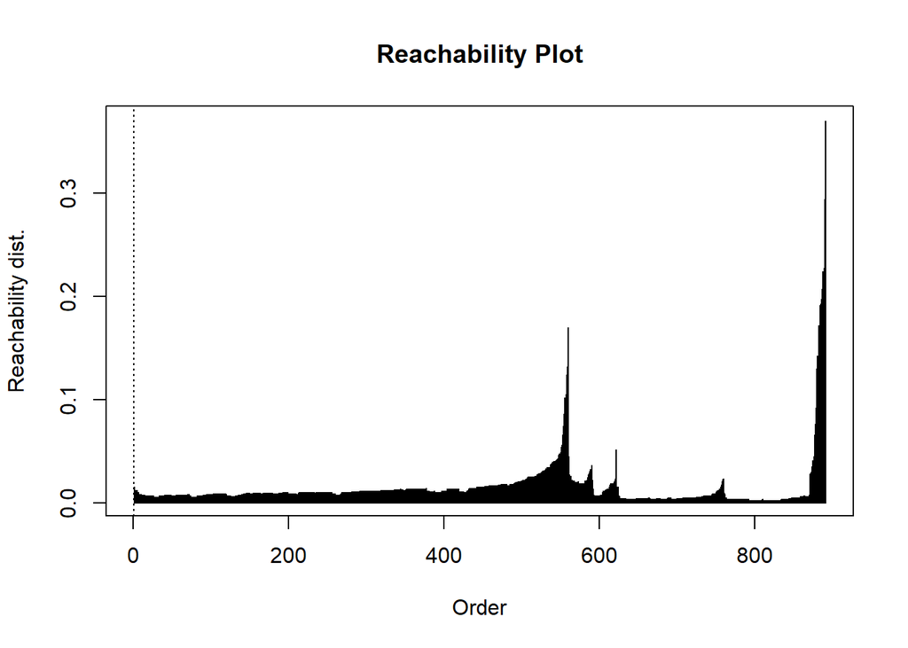

```r
plot(res_wing_weight)
```

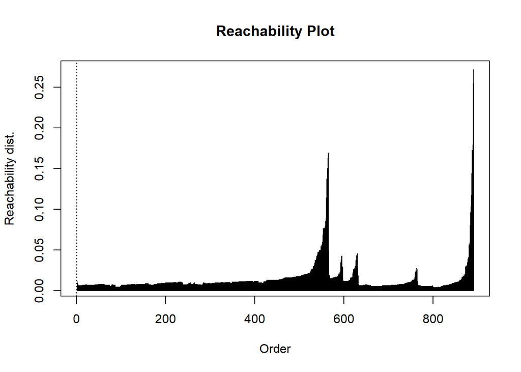

```r
plot(res_wing_culmen)
```

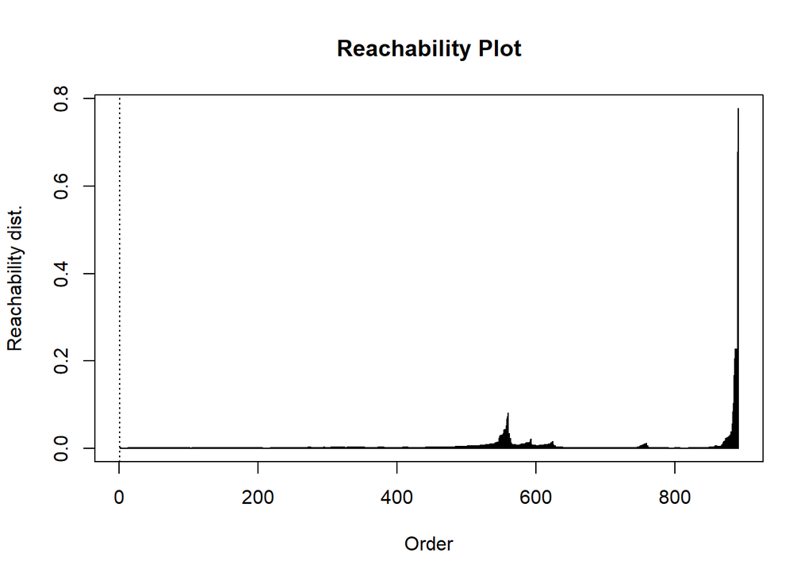

```r
plot(res_wing_hallax)
```

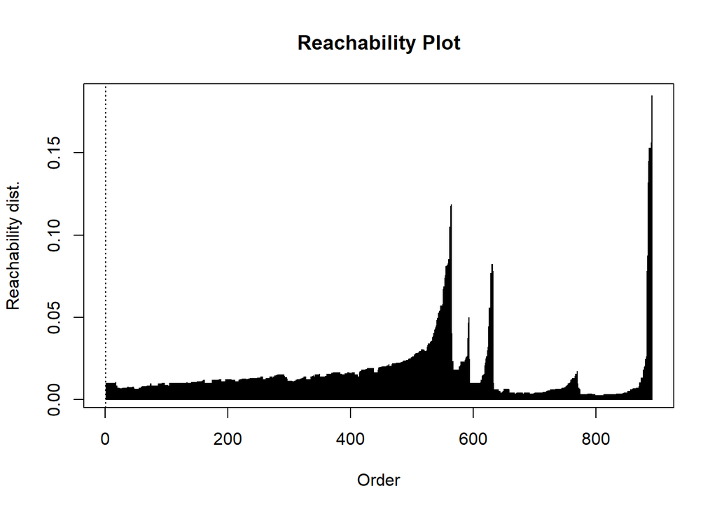

```r
plot(res_weight_culmen)
```

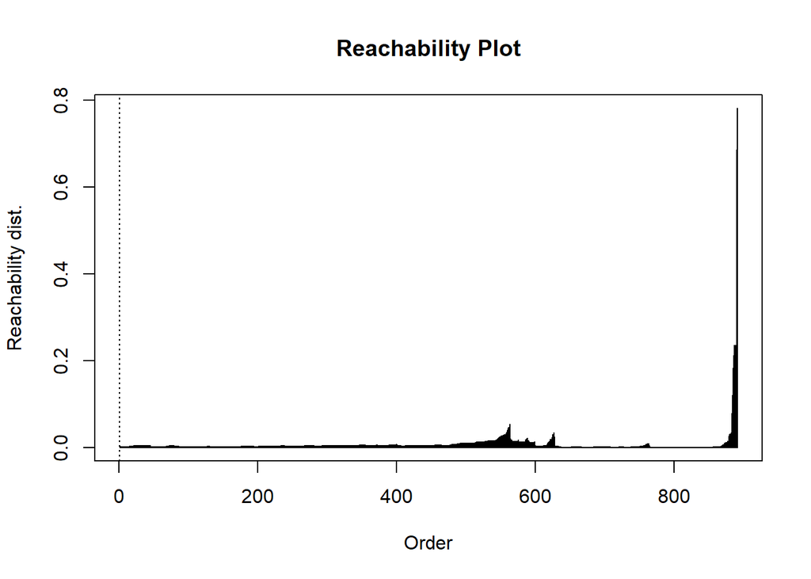

```r
plot(res_weight_hallax)
```

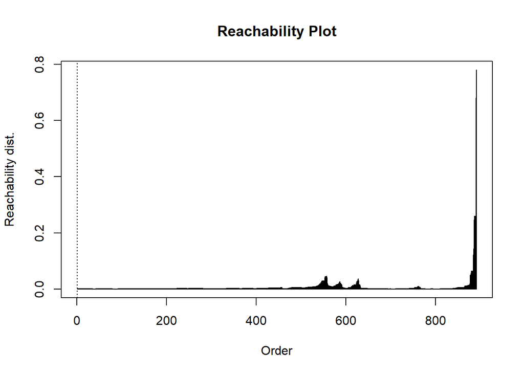

```r
plot(res_culmen_hallax)
```

Veamos otra representación del diagrama de alcanzabilidad, donde podemos observar las trazas de las distancias entre puntos cercanos del mismo cluster y entre clusters distintos.

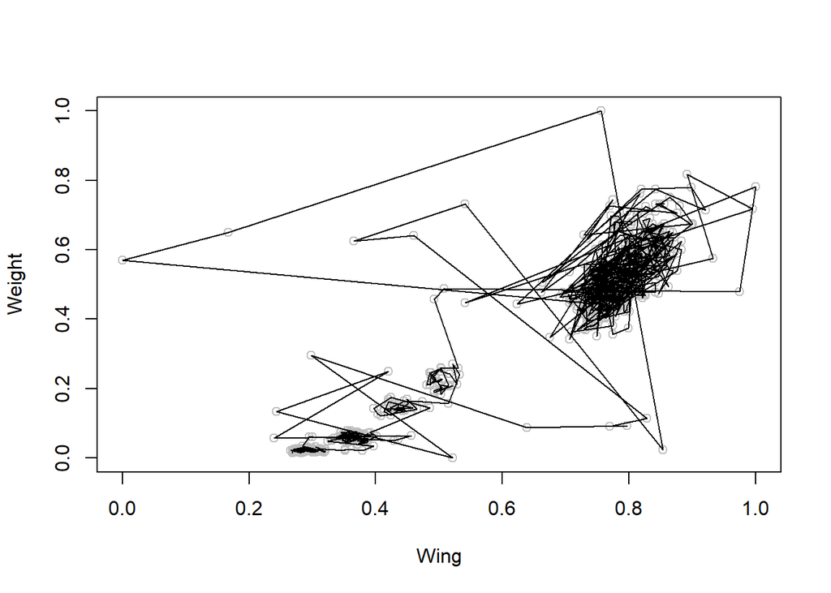

```r
plot(wing_weight, col = "grey")
polygon(wing_weight[res_wing_weight$order,])
```

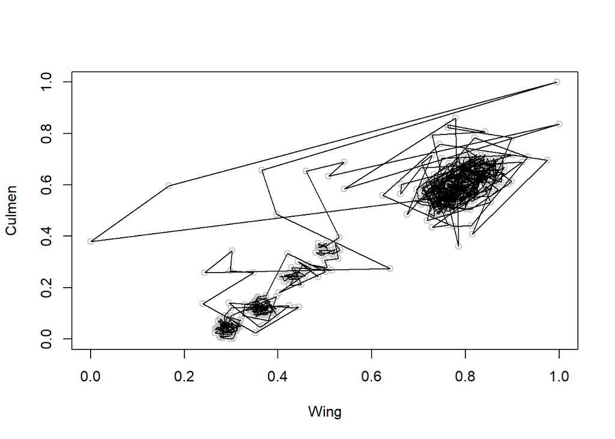

```r
plot(wing_culmen, col = "grey")
polygon(wing_culmen[res_wing_culmen$order,])
```

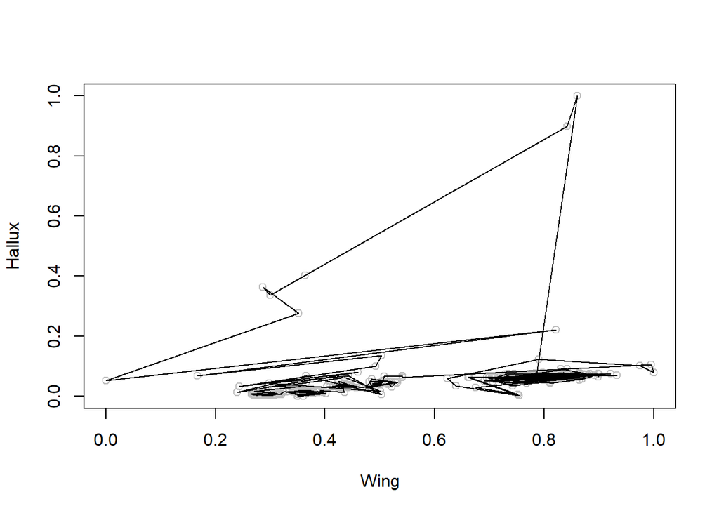

```r
plot(wing_hallax, col = "grey")
polygon(wing_hallax[res_wing_hallax$order,])
```

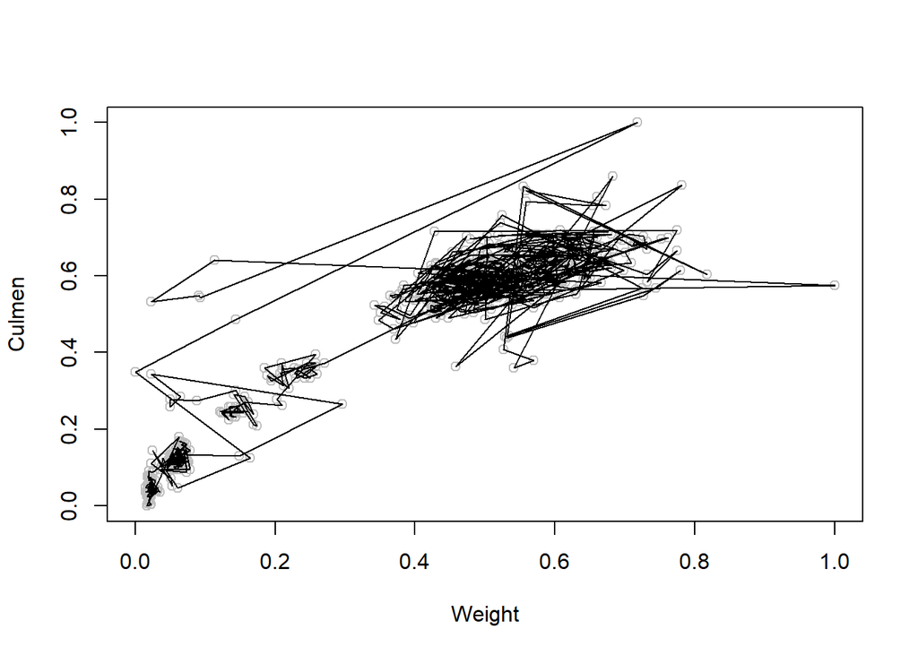

```r
plot(weight_culmen, col = "grey")
polygon(weight_culmen[res_weight_culmen$order,])
```

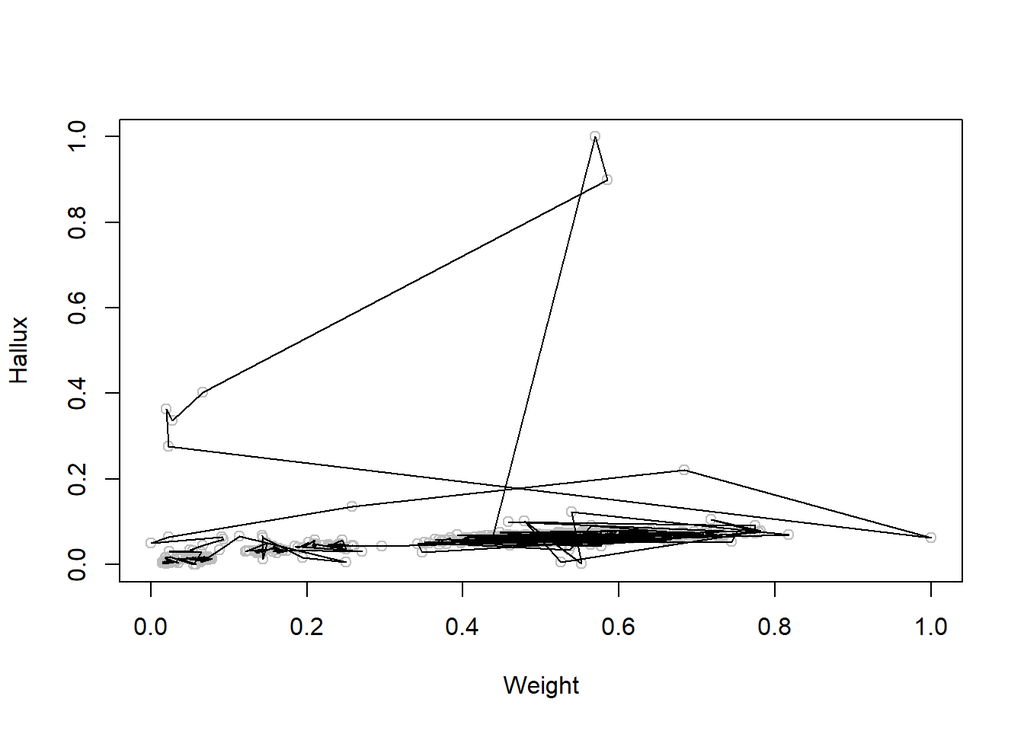

```r
plot(weight_hallax, col = "grey")
polygon(weight_hallax[res_weight_hallax$order,])
```

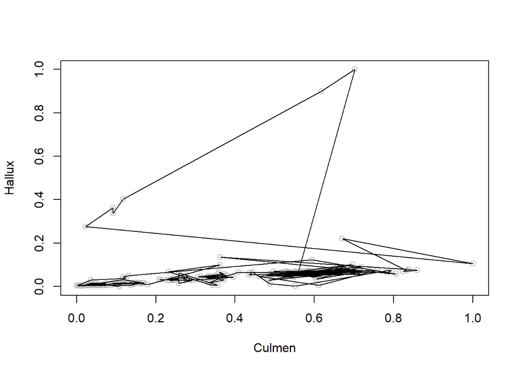

```r
plot(culmen_hallax, col = "grey")
polygon(culmen_hallax[res_culmen_hallax$order,])
```

#### DBSCAN

```r
res_wing_weight <- extractDBSCAN(res_wing_weight, eps_cl = 0.06)
res_wing_weight
```

```
## OPTICS ordering/clustering for 891 objects.
## Parameters: minPts = 10, eps = 0.564691693714801, eps_cl = 0.06, xi = NA
## The clustering contains 2 cluster(s) and 22 noise points.
##
##   0   1   2
##  22 552 317
##
## Available fields: order, reachdist, coredist, predecessor, minPts, eps,
##                   eps_cl, xi, cluster
```

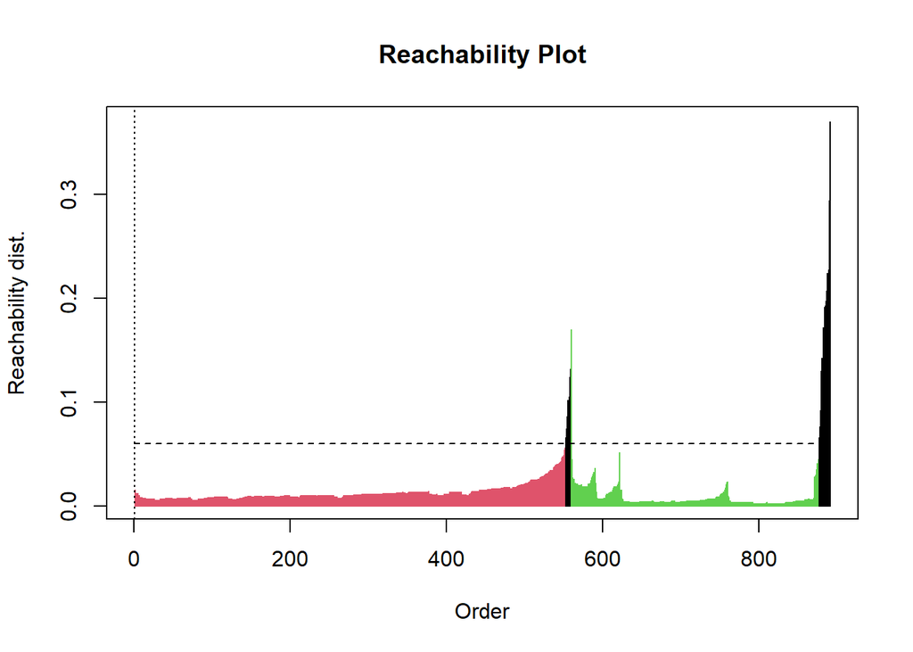

```r
plot(res_wing_weight)
```

```r
res_wing_culmen <- extractDBSCAN(res_wing_culmen, eps_cl = 0.06)
res_wing_culmen
```

```
## OPTICS ordering/clustering for 891 objects.
## Parameters: minPts = 10, eps = 0.409026103626258, eps_cl = 0.06, xi = NA
## The clustering contains 2 cluster(s) and 21 noise points.
##
##   0   1   2
##  21 552 318
##
## Available fields: order, reachdist, coredist, predecessor, minPts, eps,
##                   eps_cl, xi, cluster
```

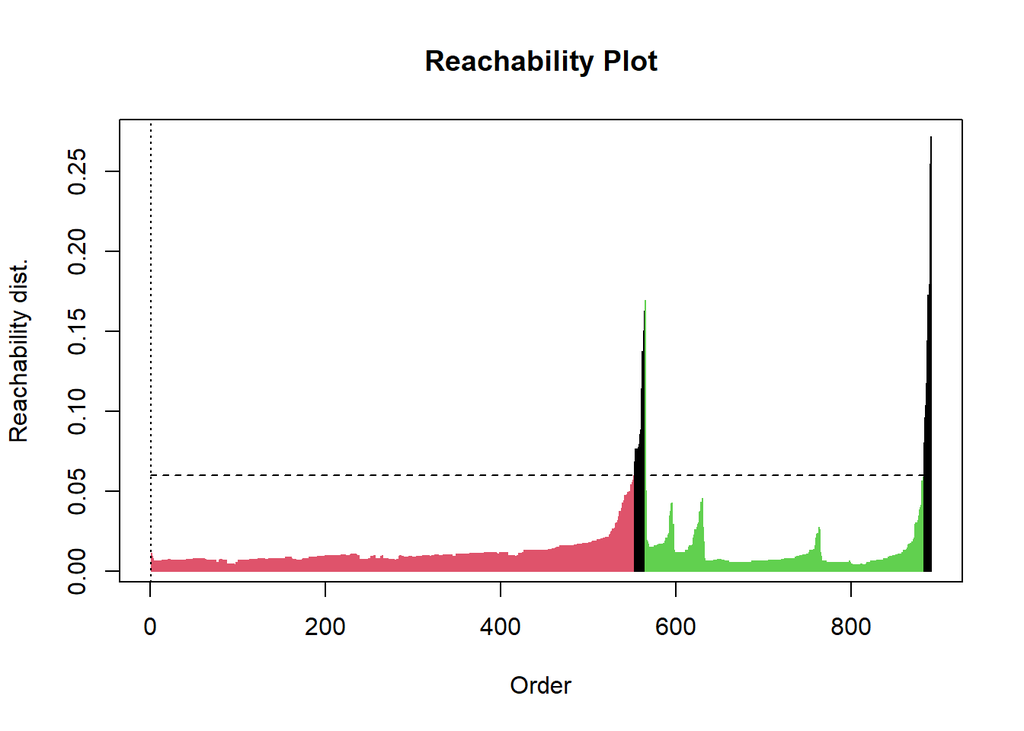

```r
plot(res_wing_culmen)
```

```r
res_wing_hallax <- extractDBSCAN(res_wing_hallax, eps_cl = 0.06)
res_wing_hallax
```

```
## OPTICS ordering/clustering for 891 objects.
## Parameters: minPts = 10, eps = 0.908887026048843, eps_cl = 0.06, xi = NA
## The clustering contains 2 cluster(s) and 11 noise points.
##
##   0   1   2
##  11 557 323
##
## Available fields: order, reachdist, coredist, predecessor, minPts, eps,
##                   eps_cl, xi, cluster
```

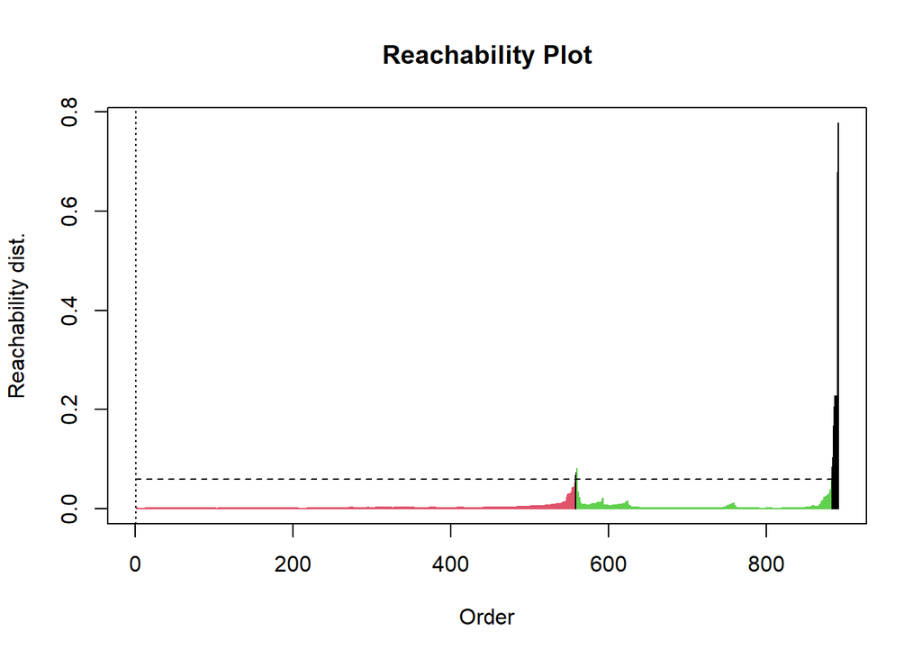

```r
plot(res_wing_hallax)
```